# chk Families

## Introduction

The `vld_` functions are used within the `chk_` functions. The `chk_` functions (and their `vld_` equivalents) can be divided into the following families.

In the code in this examples, we will use `vld_*` functions

If you want to learn more about the logic behind some of the functions explained here, we recommend reading the book [Advanced R](https://adv-r.hadley.nz/) (Wickham, 2019).

For reasons of space, the `x_name = NULL` argument is not shown. For a more simplified list of the `chk` functions, you can see the [Reference](https://poissonconsulting.github.io/chk/reference/index.html) section.

## `chk_` Functions

### Overview

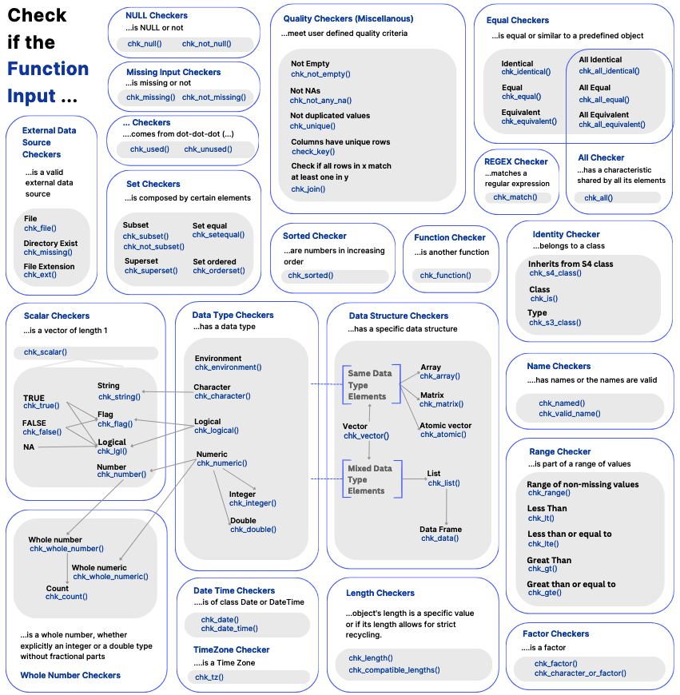

### Missing Input Checker

Check if the function input is missing or not

`chk_missing` function uses `missing()` to check if an argument has been left out when the function is called.

| Function | Code |
| --- | --- |
| `chk_missing()` | `missing()` |
| `chk_not_missing()` | `!missing()` |

### `...` Checker

Check if the function input comes from `...` (`dot-dot-dot`) or not

The functions `chk_used(...)` and `chk_unused(...)` check if any arguments have been provided through `...` (called `dot-dot-dot` or ellipsis), which is commonly used in R to allow a variable number of arguments.

| Function | Code |
| --- | --- |
| `chk_used(...)` | `length(list(...)) != 0L` |
| `chk_unused(...)` | `length(list(...)) == 0L` |

### External Data Source Checkers

Check if the function input is a valid external data source.

These `chk` functions check the existence of a file, the validity of its extension, and the existence of a directory.

| Function | Code |
| --- | --- |
| `chk_file(x)` | `vld_string(x) && file.exists(x) && !dir.exists(x)` |
| `chk_ext(x, ext)` | `vld_string(x) && vld_subset(tools::file_ext(x), ext)` |
| `chk_dir(x)` | `vld_string(x) && dir.exists(x)` |

### NULL checker

Check if the function input is NULL or not

| Function | Code |
| --- | --- |
| `chk_null(x)` | `is.null(x)` |
| `chk_not_null(x)` | `!is.null(x)` |

### Scalar Checkers

Check if the function input is a scalar. In R, scalars are vectors of length 1.

| Function | Code |
| --- | --- |
| `chk_scalar(x)` | `length(x) == 1L` |

The following functions check if the functions inputs are vectors of length 1 of a particular data type. Each data type has a special syntax to create an individual value or “scalar”.

| Function | Code |
| --- | --- |
| `chk_string(x)` | `is.character(x) && length(x) == 1L && !anyNA(x)` |
| `chk_number(x)` | `is.numeric(x) && length(x) == 1L && !anyNA(x)` |

For logical data types, you can check flags using `chk_flag()`, which considers `TRUE` or `FALSE` as possible values, or use `chk_lgl()` to verify if a scalar is of type logical, including NA as element.

| Function | Code |
| --- | --- |
| `chk_flag(x)` | `is.logical(x) && length(x) == 1L && !anyNA(x)` |
| `chk_lgl(x)` | `is.logical(x) && length(x) == 1L` |

It is also possible to check if the user-provided argument is only `TRUE` or only `FALSE`:

| Function | Code |
| --- | --- |
| `chk_true(x)` | `is.logical(x) && length(x) == 1L && !anyNA(x) && x` |
| `chk_false(x)` | `is.logical(x) && length(x) == 1L && !anyNA(x) && !x` |